# **The Most Popular Fire Emblem Characters**

By: Matt Fox and Vernon Edejer

# Introduction

Fire Emblem Heroes (FEH) is a mobile (IOS/Android) game that compiles characters from the Fire Emblem series of games. There are 16 mainline Fire Emblem games including remakes as of May 2022, so there are a huge number of characters that have the potential to make an appearance in FEH. Every year since 2017, FEH conducts a survey of the most popular Fire Emblem characters, called Choose Your Legends (CYL). Participants can vote up to 7 times per year, on different characters each time or the same one. The top 2 men and top 2 women are added into FEH as playable characters. Winners cannot be voted on in subsequent years. The results from each year are compiled [here](https://vote6.campaigns.fire-emblem-heroes.com/en-US/about). Additional information about the games and the CYL event can be found on the [Fire Emblem Wiki](https://fireemblem.fandom.com/wiki/Choose_Your_Legends)

This tutorial will compile the data of votes throughout the surveys to determine the most popular Fire Emblem characters. This will include analysis on static popularity, popularity over time, most voted on games/characters, and so on. Theoretically this data could be used to predict the next winners of Choose Your Legends, assuming a new game doesn't come out this year. The goal is to answer the questions of which character is the most popular and who is likely to win next year.

Read more about the libraries we used here: [MatPlotLib](https://matplotlib.org/stable/index.html), [numpy](https://numpy.org/doc/), [pandas](https://pandas.pydata.org/docs/), [Python Statistics](https://docs.python.org/3/library/statistics.html), [Python Regex](https://docs.python.org/3/library/re.html), [statsmodels](https://www.statsmodels.org/stable/index.html), and [seaborn](https://seaborn.pydata.org/tutorial.html).

```python
import matplotlib.pyplot as plt
import numpy as np
import pandas as pd
import re
import seaborn as sb
import statistics as stats
from statsmodels.formula.api import ols

from google.colab import drive
drive.mount('/content/drive')

import warnings
warnings.filterwarnings('ignore')
```

```python
winners = ['Lyn', 'Ike', 'Lucina', 'Roy', 'Hector', 'Celica', 'Ephraim', 'Veronica', 'Alm', 'Micaiah', 'Eliwood', 'Camilla', 'Edelgard', 'Dimitri', 'Lysithea', 'Claude', 'Gatekeeper', 'Marianne', 'Marth', 'Eirika', 'Chrom', 'Tiki', 'Seliph', 'Byleth (female)']
```

# Collecting and Parsing the Data

To set up, we first grab the data from the downloaded html of the CYL website's dataset. There were a few regex strings that we needed to use to filter the data into readable formats. We also had to normalize the column names because the conventions for storing the data must have changed from year to year.

```python
html_page = pd.read_html("drive/MyDrive/Colab Notebooks/htm files/cyl6_1.htm")
#html_page = pd.read_html("htm files/cyl6_1.htm") # using this for running within IDE

df = html_page[0]

# regex to match when a name and title are adjacent
name_reg = "[^\s^\'^\(^\♯FE][A-Z]"
# regex to match "double" characters (arvis and byleth)
byleth_reg = "Byleth\s\((male|female)(.*)(Three Houses \(Academy Arc\))"
arvis_reg = "Arvis(.*)(Genealogy of the Holy War)"
# regex to match "sequel" titles
gene_reg = "Genealogy"
three_reg = "Three"
shadow_reg = "Shadow"
radiant_reg = "Radiant"
repl = "|"
# rename NameTitle column to match other tables
def nameTitle(df):
  if 'Name  Title' in df.columns:
    df.rename(columns={'Name  Title':'NameTitle'}, inplace=True)

  return df

df = nameTitle(df)
df.head()
```

|  | Rank | NameTitle | Votes |
| --- | --- | --- | --- |
| 0 | 1 | ChromAwakening | 42134 |
| 1 | 2 | TikiAwakening | 39705 |
| 2 | 3 | SeliphGenealogy of the Holy War | 26301 |
| 3 | 4 | Byleth (female)Byleth (female, Enlightened)Thr... | 20855 |
| 4 | 5 | BernadettaThree Houses (War Arc)Three Houses (... | 19335 |

As you can see, the html table didn't bother to separate the name of the characters and the title from which they originated. This is where the regex strings come in. Luckily for us, though, there is no missing data; the tables from the website are all fully complete.

```python
def split_nametitle(df):
  # identify the regex match, add the repl string in between them
  entry_list = []
  for entry in df['NameTitle']:
    # check if byleth is in this entry, if so reformat that entry
    byleth_match = re.search(byleth_reg, entry)
    arvis_match = re.search(arvis_reg, entry)
    if (byleth_match is not None):
      entry = "Byleth (" + byleth_match.group(1) + ")" + byleth_match.group(3)
    if (arvis_match is not None):
      entry = "Arvis" + arvis_match.group(2)

    match = re.search(name_reg, entry)
    new_entry = entry[:match.start() + 1] + repl + entry[match.start() + 1:]
    entry_list.append(new_entry)

  new_entry = ""

  # create the new Name and Title columns separately
  df['NameTitle'] = entry_list
  df[['Name', 'Title']] = df['NameTitle'].str.split(repl, 1, expand=True)
  df = df.drop(['NameTitle'], axis=1)
  # reorder the columns
  df = df[['Rank', 'Name', 'Title', 'Votes']]

  return df

df = split_nametitle(df)
df.head()
```

|  | Rank | Name | Title | Votes |
| --- | --- | --- | --- | --- |
| 0 | 1 | Chrom | Awakening | 42134 |
| 1 | 2 | Tiki | Awakening | 39705 |
| 2 | 3 | Seliph | Genealogy of the Holy War | 26301 |
| 3 | 4 | Byleth (female) | Three Houses (Academy Arc) | 20855 |
| 4 | 5 | Bernadetta | Three Houses (War Arc)Three Houses (Academy Arc) | 19335 |

We iterate through each entry in "NameTitle" and match it with our regex which identifies where there is a non-space non-special character followed by a capital letter. At that index, we split up the two entries. You may notice that some characters are listed with two names: since this only occurred on two characters in the series (Byleth and Arvis) we used special regex strings to filter those out and rename them to just one name. There are also some titles which were inconsistently recorded. For example, appearing in "Path of Radiance" and "Radiant Dawn" could be recorded as either "Path of Radiance | Radiant Dawn" or "Radiant Dawn | Path of Radiance". These cases were normalized using regex. After iteration, we split up the NameTitle column into two separate columns for readability sake. Lastly the columns are reordered into Rank, Name, Title, and Votes.

```python
def split_titles(df):
  title_list = []
  # identify if there are 2 titles and reformat them
  for title in df['Title']:
    match = re.search(name_reg, title)
    if (match is not None):
      new_entry = title[:match.start() + 1] + " " + repl + " " + title[match.start() + 1:]
      # check if there are more than 2 titles
      check_match = re.search(name_reg, new_entry)
      if (check_match is not None):
        new_entry = new_entry[:check_match.start() + 1] + " " + repl + " " + new_entry[check_match.start() + 1:]
    else:
      new_entry = title

    title_list.append(new_entry)

  # set the title column to our new split version
  df['Title'] = title_list
  title_list = []

  # check and reorder multiple titles
  for title in df['Title']:
    gene_match = re.search(gene_reg, title)
    three_match = re.search(three_reg, title)
    shadow_match = re.search(shadow_reg, title)
    radiant_match = re.search(radiant_reg, title)

    # match Geneology of the Holy War
    if gene_match is not None and '|' in title:
      new_entry = "Genealogy of the Holy War | Thracia 776"
    # match Three Houses
    elif (three_match is not None and '|' in title):
      new_entry = "Three Houses (Academy Arc) | Three Houses (War Arc)"
    # match Shadow Dragon
    elif shadow_match is not None and '|' in title:
      new_entry = "Shadow Dragon and the Blade of Light / Shadow Dragon | Mystery of the Emblem / New Mystery of the Emblem"
    # match Radiant Dawn
    elif radiant_match is not None and '|' in title:
      new_entry = "Path of Radiance | Radiant Dawn"
    else:
      new_entry = title

    title_list.append(new_entry)

  # set the title column to our new split and reordered version
  df['Title'] = title_list

  return df

df = split_titles(df)
df
```

|  | Rank | Name | Title | Votes |
| --- | --- | --- | --- | --- |
| 0 | 1 | Chrom | Awakening | 42134 |
| 1 | 2 | Tiki | Awakening | 39705 |
| 2 | 3 | Seliph | Genealogy of the Holy War | 26301 |
| 3 | 4 | Byleth (female) | Three Houses (Academy Arc) | 20855 |
| 4 | 5 | Bernadetta | Three Houses (Academy Arc) \| Three Houses (War... | 19335 |
| ... | ... | ... | ... | ... |
| 205 | 197 | Kiragi | Fates | 495 |
| 206 | 198 | Camus | Shadow Dragon and the Blade of Light / Shadow ... | 493 |
| 207 | 199 | Ricken | Awakening | 491 |
| 208 | 199 | Meg | Radiant Dawn | 491 |
| 209 | 200 | Shura | Fates | 489 |

210 rows × 4 columns

Some characters appear in multiple titles throughout the series. For these cases, we iterate through the new title column and split them up just as before if necessary. Finally, our data is nice and neat in the tables.

# Combining the Data

Next, since each year's results are on separated HTM files and tables, we have to do some work to combine them together. This will involve tagging each year accordingly in a new 'Year' column, as well as running our previous functions on each of the tables.

```python
# read each htm file

round_one = pd.read_html("drive/MyDrive/Colab Notebooks/htm files/cyl1_1.htm")[0]
round_two = pd.read_html("drive/MyDrive/Colab Notebooks/htm files/cyl2_1.htm")[0]
round_three = pd.read_html("drive/MyDrive/Colab Notebooks/htm files/cyl3_1.htm")[0]
round_four = pd.read_html("drive/MyDrive/Colab Notebooks/htm files/cyl4_1.htm")[0]
round_five = pd.read_html("drive/MyDrive/Colab Notebooks/htm files/cyl5_1.htm")[0]
round_six = pd.read_html("drive/MyDrive/Colab Notebooks/htm files/cyl6_1.htm")[0]

all_rounds = [round_one, round_two, round_three, round_four, round_five, round_six]
cyl_dfs = []
year = 2017

# iterate through each round, adding a year column and cutting off all but the
# top 100
for round_data in all_rounds:
  round_data = split_titles(split_nametitle(nameTitle(round_data)))
  round_data = round_data.loc[round_data['Rank'] < 101]
  round_data['Year'] = year
  cyl_dfs.append(round_data)
  year += 1

# The rows exceed 600 due to ties in the data
cyl_df = pd.concat(cyl_dfs, ignore_index=True)
cyl_df.head()
```

|  | Rank | Name | Title | Votes | Year |
| --- | --- | --- | --- | --- | --- |
| 0 | 1 | Lyn | The Blazing Blade | 49917 | 2017 |
| 1 | 2 | Lucina | Awakening | 42875 | 2017 |
| 2 | 3 | Ike | Path of Radiance | 33871 | 2017 |
| 3 | 4 | Tharja | Awakening | 29540 | 2017 |
| 4 | 5 | Roy | The Binding Blade | 28982 | 2017 |

First, we call read_html for each of the HTM files of results. Then, we store all of those into an array to iterate through, call our functions, and add the year column. Lastly we combine the parsed tables using the pandas concat function. A few things to note: one, we trimmed the data at this stage to only look at the top 100 for each year since this data was the most interesting to analyze. Even so, there are more than 600 entries. This is because some years there were ties. For example, in 2022 both Sain and Lute received 995 votes. We decided to keep these ties in the table since there are so few of them and they could be interesting points of discussion.

[figure not shown]

*The winners of CYL Round 1: Roy, Ike, Lyn, and Lucina (left to right)*

# Exploratory Data Analysis

We decided to make graphs for:

- Number of total votes each year
- Characters with the most total votes
- Games (Titles) with the most total votes
- Range of votes each year
- Number of votes per character over time

These graphs should give us a good measure of different types of popularity and how it changes over time. They give us context to each other and allow us to make more informed conclusions rather than just looking at the characters who had the most votes.

### Bar Graph of Votes Each Year

To create this graph we use a pandas groupby in terms of year, then iterate through that object, summing the votes in each group. Matplotlib's .bar() function is used to display the data.

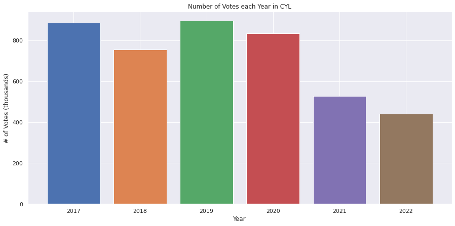

```python
grouped_by_year = cyl_df.groupby('Year')
fig = plt.figure(figsize=(15,7))

for year, group in grouped_by_year:
  plt.bar(year, group['Votes'].sum() / 1000)

plt.xlabel("Year")
plt.ylabel("# of Votes (thousands)")
plt.title("Number of Votes each Year in CYL")
plt.show()
```

This bar graph shows the number of votes each year. Something striking at first glance is that the number of votes trends downwards as time goes on. This could be due to several factors. One theory is that in the beginning CYL was a big newsworthy event, but as time goes on it's just a normal thing that happens every year. Another theory could be that the playerbase of Fire Emblem Heroes is just trending downwards, and thus less people care enough to vote. Perhaps also it could be that people's characters are winning, and once their favorites have won they have no more reason to vote.

However, we also need to know the distribution of the votes and how the outlying data can affect the voting distribution. So, how can we map this distribution?

### Violin Plot of Votes Each Year

Using seaborn, we plot the ranges of votes for each character using a violin plot:

[output not shown]

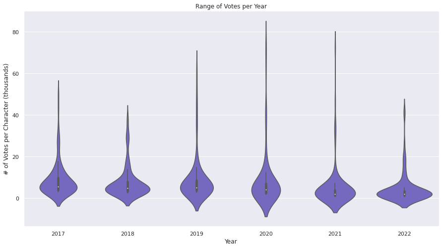

```python
# setting up the violin plot
sb.set(rc={'figure.figsize': (15,8)})
viola = sb.violinplot(x=cyl_df.Year, y=(cyl_df.Votes)/1000, color="slateblue")
viola.set(xlabel="Year", ylabel="# of Votes per Character (thousands)", title="Range of Votes per Year")
```

From the data shown on the violin plot, we note multiple observations. Firstly, the total amount of votes per year is not known, so we get a better idea of how the votes are distributed. While we see a rather consistent trend of a large spread of votes towards the 10000 range, the outlying characters are still dominating the plot, stretching out the violin thinly as the votes increase.

### Parameters of Interest

From each violin, we can also conceptualize the data by creating a dataframe that provides the parameters of interest for each year. The purpose of this is to create a conventional and practical way to refer back to the total votes, mean, median, and standard deviations.

To showcase these parameters, we have to create four empty arrays using numpy and iterate through the years in the CYL DataFrame. For each year, we get the following data:

- Total Votes
- Mean Votes
- Median Votes
- Standard Deviation

```python
# creating empty arrays to fill in some extra data
years = cyl_df['Year'].unique()
votes = np.empty(len(years), dtype=object)
means = np.empty(len(years), dtype=object)
medians = np.empty(len(years), dtype=object)
stdevs = np.empty(len(years), dtype=object)

# iterating through the years and finding the respective parameters of interest for the
# corresponding year
for i in range(len(years)):
    votes[i] = cyl_df.loc[cyl_df['Year'] == years[i]]['Votes'].sum()
    means[i] = cyl_df.loc[cyl_df['Year'] == years[i]]['Votes'].mean()
    medians[i] = cyl_df.loc[cyl_df['Year'] == years[i]]['Votes'].median()
    stdevs[i] = cyl_df.loc[cyl_df['Year'] == years[i]]['Votes'].std()

# putting the data into a dataframe for easier access and readability
cyl_theta = pd.DataFrame({'Year':years, 'Votes':votes, 'Mean':means, 'Median':medians, 'Std Dev':stdevs})
cyl_theta
```

|  | Year | Votes | Mean | Median | Std Dev |
| --- | --- | --- | --- | --- | --- |
| 0 | 2017 | 885029 | 8850.29 | 5526.5 | 8365.825251 |
| 1 | 2018 | 755132 | 7551.32 | 4669.5 | 7659.272289 |
| 2 | 2019 | 896076 | 8960.76 | 4946.5 | 10969.634377 |
| 3 | 2020 | 834767 | 8265.019802 | 4013.0 | 13253.776127 |
| 4 | 2021 | 527826 | 5124.524272 | 2027.0 | 10000.067389 |
| 5 | 2022 | 441068 | 4324.196078 | 1825.5 | 7018.482705 |

As said before, we can see a downwards trend of voters per year. However, standard deviations are at its peak during the steepest part of the voter count slope. We can see that there is a large portion of outlying data from 2019 to 2021. This backs up one of our first claims saying the diverse group of voters are becoming more skewed towards certain titles and characters. The reason, as said before, could be the emphasis on players' favorite characters being removed from rotation after winning in a previous year.

### Bar Graph of Most Votes

We again use pandas groupby in terms of name of character, then iterate through and record the votes over a certain threshold (the top end of voted on characters). The threshold depends on voting sum rather than any other measure because of the nature of the "elimination" in CYL. Since winners can get one year of very high votes for the win, their average will be high, but that won't be useful for statistical and visual analysis. More on excluding early winners will be discussed in the conclusion.

[figure not shown]

```python
grouped_by_char = cyl_df.groupby('Name')
fig = plt.figure(figsize=(15,8))
top_chars = list()

# iterate through each character and graph their votes if greater than a threshold
for char, group in grouped_by_char:
  if group['Votes'].sum() >= 80000:
    plt.bar(char, group['Votes'].sum() / 1000, width=0.5)
    top_chars.append(char) # making a list of the top characters to use for future plots

plt.xlabel("Character")
plt.ylabel("# of Votes (thousands)")
plt.title("Most Voted on in CYL")
plt.show()
```

This bar graph shows the most voted on characters in CYL over all available data. While one could reasonably say that Marth is the most popular character based on this chart alone, it is not that simple. Marth has been available to vote for since the beginning of CYL in 2017 (meaning he appeared in a game before 2017), and didn't win until 2021. In comparison, Byleth (female) was only available to vote for since 2020, yet still has roughly half of Marth's total votes (she won in 2022). Additionally, there are characters like Anna, who appear in several games but their votes are counted separately. This means that a graph showing the most voted on characters is only one step towards identifying the most popular Fire Emblem character. We still have some work to do.

[figure not shown]

*Marth, the most voted on character in CYL history*

### Line Plot of All Characters

This code uses the group by character group that we made before, and records each character's votes over time to plot on a line graph. This will hopefully let us identify spikes in popularity and consistency across voting periods.

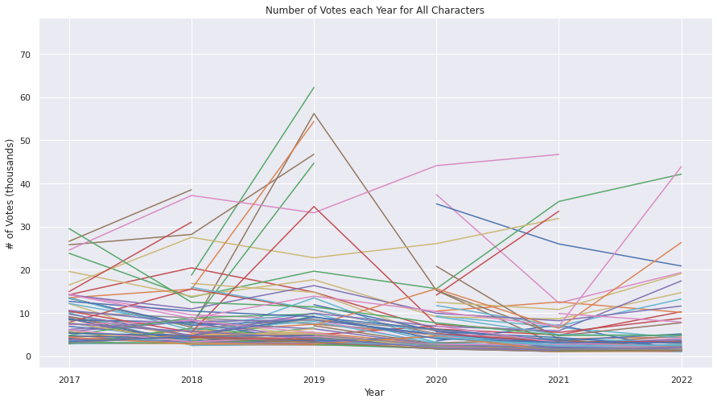

```python
for char, group in grouped_by_char:
    group = group.groupby('Year').sum().reset_index()
    sb.lineplot(x=group.Year, y=group.Votes/1000)

plt.title("Number of Votes each Year for All Characters")
plt.xlabel("Year")
plt.ylabel("# of Votes (thousands)")
plt.show()
plt.clf()
```

Clearly, the data provides no useful information in this form. We're going to have to trim it down to get some useful information out of it.

### Line Plot of Top Characters

The below code uses the groups by character and a new group by year for each of them. We then used seaborn's lineplot function to plot the votes over time for several characters. Since the data of all characters was extremely noisy and hard to read, we cut off all but the top end just as we did before with the bar graph.

[figure not shown]

```python
legend = []

for char, group in grouped_by_char:
  if char in top_chars:
    group = group.groupby('Year').sum().reset_index()
    sb.lineplot(x=group.Year, y=group.Votes/1000)
    legend.append(char)

plt.legend(labels=legend)
plt.title("Number of Votes each Year for Top Characters")
plt.xlabel("Year")
plt.ylabel("# of Votes (thousands)")
```

We can see some interesting data from this line plot. Marth it seems was among the most popular extremely consistently until his win in 2021. Eirika seems to be close behind him in consistency as well, and they won in the same year. Additionally there are some outliers denoted by spikes in the graph. Alm, for example, while he was votable in 2017, didn't even appear among the most popular, but then surged in popularity from 2018-2019 where he won. This could be entirely due to a remake of his game coming out in 2017 after CYL votes were in. Anna also has some interesting data. She remains among the most voted on characters every year, but has still not been a winner. She had a large spike in 2019, likely due to a rally in votes that ended up not winning her the top spot. It could be that Anna voters got discouraged after this, which would explain her return and decline to normal voting numbers.

Keep in mind, however, that we saw the total votes go down from year to year. This means that in general popular characters should get less votes as time goes on. Any huge spikes in opposition to this trend point to an extremely popular character or some other outlying situation. Additionally, this graph doesn't include all the winners from each year. This is because many winners simply won without much time to garner many votes, or won in the same year that they were first available to vote on.

### Line Plot of Top Non-Winners

[figure not shown]

```python
legend = []

for char, group in grouped_by_char:
  if char not in winners and stats.mean(group['Votes']) > 10500:
    group = group.groupby('Year').mean().reset_index()
    sb.lineplot(x=group.Year, y=group.Votes/1000)
    legend.append(char)

plt.legend(labels=legend)
plt.title("Number of Votes each Year for Top Non-Winners")
plt.xlabel("Year")
plt.ylabel("# of Votes (thousands)")
```

### Bar Graph of Most Voted on Titles

The below code groups the data by Titles, then iterates through to count the total votes for each title.

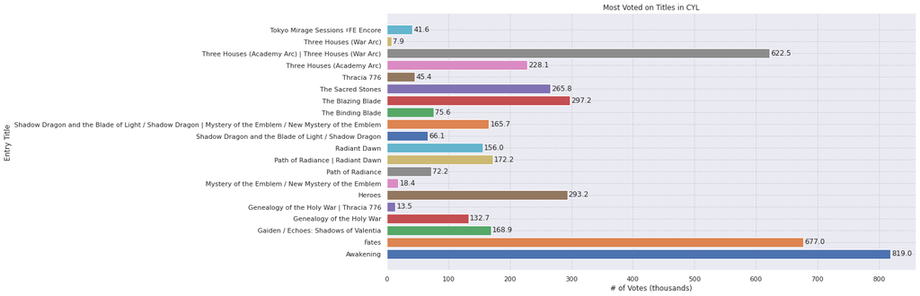

```python
grouped_by_title = cyl_df.groupby('Title')
fig = plt.figure(figsize=(16,8))
count = 0

# simple function to count the number of characters in a string
def count_char(s, c):
  num = 0
  for i in s:
    if i == c:
      num+=1

  return num

# iterate through the title groups and count their votes, and graph it
for title, group in grouped_by_title:
  if not count_char(title, '|') >= 2:
    vote_sum = group['Votes'].sum() / 1000
    plt.barh(title, vote_sum)
    plt.text(vote_sum+2, count-0.15, str(int(vote_sum * 10) / 10))
    count += 1

plt.grid(b = True, color ='grey',
        linestyle ='-.', linewidth = 0.5,
        alpha = 0.5)

plt.xlabel("# of Votes (thousands)")
plt.ylabel("Entry Title")
plt.title("Most Voted on Titles in CYL")
plt.show()
```

This graph is the same as the last one except it looks at all the titles rather than characters. There are many interesting things to take away. For one, it's clear that some titles on their own don't have many votes, but when considering characters from two games (with those titles included) have a significant number of votes. One reason for this could be that characters are simply more likely to show up in both of the games in a duo than only one. More characters to vote for means higher vote totals.

Given what we know now about certain characters' popularity, namely Marth, this data gives a lot of information about how votes are distributed across titles. The games that Marth hails from (Shadow Dragon and Mystery of the Emblem and their remakes) have a pretty low vote total in comparison to other games. Yet, Marth is the most voted on character despite this. This tells us both about the prevalence of Marth as a character and the voting patterns among other games. Other games have far and away the most votes (the most recent 3 games, Three Houses, Awakening, and Fates are the highest), but only have half of the most voted on characters. Corrin, Chrom, Byleth, Tiki, and Camilla are the characters in those games in the top 10 voted on. This tells us that votes on these recent titles are mostly spread out among many characters. It could be that popularity in these titles are more impressive considering the increased competition.

[figure not shown]

*Fire Emblem: Awakening, the most voted title*

# Preparing for the Regression

```python
# function to use to map each row to get the voting proportions for each year
def getVoteRatio(row, year):
  return row['Votes']/cyl_theta.loc[cyl_theta['Year']==year]['Votes']

# applying the lambda function and adding a column to represent the voting ratios
for i in years:
  cyl_df['VoteRatio'] = cyl_df.apply(lambda row: getVoteRatio(row, i), axis=1)

# reformatting the data frame (anna is a special case so we remove her - appears in three different entries
top_proportions = cyl_df.loc[cyl_df['Name'] != 'Anna'].reset_index()[['Rank', 'Name', 'Title', 'Votes', 'VoteRatio', 'Year']]
top_proportions = top_proportions.sort_values(by='VoteRatio', ascending=False)
top_proportions
```

|  | Rank | Name | Title | Votes | VoteRatio | Year |
| --- | --- | --- | --- | --- | --- | --- |
| 293 | 1 | Edelgard | Three Houses (Academy Arc) \| Three Houses (War... | 74617 | 0.169173 | 2020 |
| 392 | 1 | Gatekeeper | Three Houses (Academy Arc) | 72267 | 0.163845 | 2021 |
| 294 | 2 | Dimitri | Three Houses (Academy Arc) \| Three Houses (War... | 69448 | 0.157454 | 2020 |
| 196 | 1 | Alm | Gaiden / Echoes: Shadows of Valentia | 62216 | 0.141058 | 2019 |
| 295 | 3 | Claude | Three Houses (Academy Arc) \| Three Houses (War... | 59751 | 0.135469 | 2020 |
| ... | ... | ... | ... | ... | ... | ... |
| 593 | 99 | Athos | The Blazing Blade | 982 | 0.002226 | 2022 |
| 594 | 100 | Seiros | Three Houses (War Arc) | 979 | 0.002220 | 2022 |
| 491 | 98 | Volke | Path of Radiance \| Radiant Dawn | 978 | 0.002217 | 2021 |
| 492 | 99 | Pelleas | Radiant Dawn | 948 | 0.002149 | 2021 |
| 493 | 100 | Manuela | Three Houses (Academy Arc) | 941 | 0.002133 | 2021 |

595 rows × 6 columns

Next we make a dataframe to calculate the average vote ratio per character and over time. If the character only appeared once in our top 100 data, we exclude them, since there isn't enough data to go off of. We also separate data of winners to compare to later. Lastly, we filter out the very low vote proportions to just look at the top end of popularity.

```python
names = top_proportions['Name'].unique()
winners2022 = ['Chrom', 'Tiki', 'Seliph', 'Byleth (female)']

# creating the arrays to use as columns in the new dataframe
means = np.empty(len(names), dtype="object") # mean number of votes
appearances = np.empty(len(names), dtype="object") # list of votes per year

# for each name we get the amount of vote ratios to calculate the mean for each character
for id in range(len(names)):
    appearances[id] = top_proportions.loc[top_proportions['Name'] == names[id]]['VoteRatio'].tolist()

    # if theyve only appeared once - ignore them, there's not enough data
    if (len(appearances[id]) > 1):
      means[id] = stats.mean(appearances[id])

# creating the dataframe to visualize the information
params_per_char = pd.DataFrame({'Name':names, 'Average':means})

# separate data frame for the winners
params_winners = params_per_char[params_per_char.Name.isin(winners2022)]

# remove the winners from this dataframe and filter out the low average vote proportions
params_per_char = params_per_char[~params_per_char.Name.isin(winners)]
params_per_char = params_per_char[params_per_char['Average'] > 0.02]
params_per_char.head()
```

|  | Name | Average |
| --- | --- | --- |
| 15 | Bernadetta | 0.052158 |
| 18 | Robin (female) | 0.027225 |
| 23 | Tharja | 0.026703 |
| 28 | Azura | 0.026761 |
| 29 | Corrin (female) | 0.031538 |

```python
params_winners.head()
```

|  | Name | Average |
| --- | --- | --- |
| 12 | Chrom | 0.056921 |
| 13 | Tiki | 0.014805 |
| 17 | Byleth (female) | 0.062027 |
| 26 | Seliph | 0.031419 |

The averages by themselves aren't significantly different between winners and non-winners. In some cases non-winners have higher average vote proportions than winners. The interesting point of comparison will be when we take year into account.

## Regression Modeling

Our hypothesis is that, in general, vote proportion trends downwards over time. This assumption comes from the combination of total votes trending downwards each year and the increase in character pool each year. Given this thought, it would make sense that characters who defy the trend and have increasing vote proportions tend to win or at least signify extremely popular characters.

To test our hypothesis, we have to run a regression on each of the top characters and each of the winners. We separate winners and non-winning top characters out, plot their vote proportion data, then use statsmodels to fit a regression onto the data.

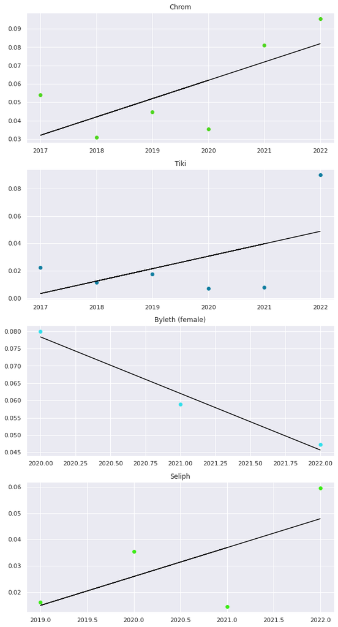

```python
winner2022_names = params_winners['Name'].unique()
fig, axes = plt.subplots(len(winner2022_names), 1, figsize=(10,20))

# Regression plot for last years winners
for i in range(len(winner2022_names)):

  # extracting the dataframe for the necessary character to make the regression
  if (winner2022_names[i] != 'Tiki'):
    x = top_proportions.loc[top_proportions['Name'] == winner2022_names[i]]
  else:
    # separating Tiki so we only grab from Awakening
    x = top_proportions.loc[(top_proportions['Title'] == 'Awakening') & (top_proportions['Name'] == 'Tiki')]

  # fitting the regression line for Vote Ratio and Year
  model = ols('VoteRatio ~ Year', data=x).fit()

  # scatter plotting each point
  axes[i].scatter(x=x.Year, y=x.VoteRatio, color=np.random.rand(3,))
  axes[i].plot(x.Year, model.predict(x.Year), color="black")
  axes[i].title.set_text(winner2022_names[i])
```

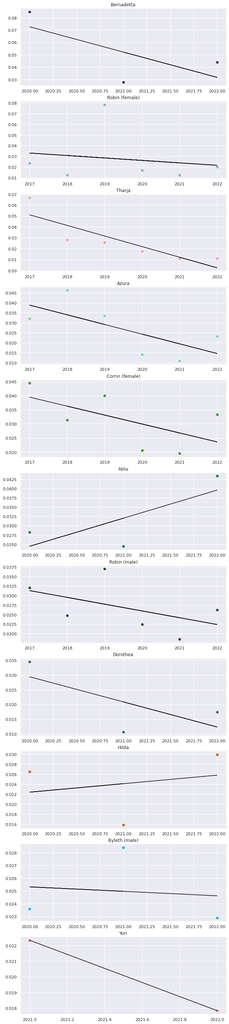

```python
param_names = params_per_char['Name'].unique()
fig, axes = plt.subplots(len(param_names), 1, figsize=(10,50))
char_slope = {}

# regression plot for each of the top characters
for i in range(len(param_names)):
  x = top_proportions.loc[top_proportions['Name'] == param_names[i]]

  model = ols('VoteRatio ~ Year', data=x).fit()

  char_slope[param_names[i]] = model.params

  axes[i].scatter(x=x.Year, y=x.VoteRatio, color=np.random.rand(3,))
  axes[i].plot(x.Year, model.predict(x.Year), color="black")
  axes[i].title.set_text(param_names[i])
```

# Conclusion - Insights Obtained

The rather naive questions asked at the beginning of this tutorial turned out to be not so easy to answer. Marth was the most voted on character throughout the short history of CYL and he was consistently a top voting choice every year until his win. It makes sense, too. Marth was the protagonist of the first Fire Emblem game, he was one of the first characters to appear in the popular Super Smash Brothers game, and he appeared in 4 of 16 Fire Emblem titles including remakes and sequels. There's no denying that Marth is one of the most recognizable Fire Emblem characters.

Examining different ways of looking at popularity can drastically change our conclusions. While it may be easy to say that Marth is the most popular character, why didn't he win earlier? Shouldn't we say that the first-ever winners are simply the most popular? Then, the second winners would be the next most popular, and so on. That doesn't make for interesting data science and we can explore much more about popularity than just winners. Our data exploration showed how many variables can affect votes. Popular titles, new releases, other non-Fire Emblem games, previous winners, and many more variables can affect spikes in popularity which could lead to a win.

All that being said, there are two main categories we will use to classify the most popular: turnout and consistency. Turnout is reliant on number of total votes, and takes into account game popularity as well as voting numbers for a given year. **Marth** seems to be the character with the best turnout. Consistency refers to turnout over time, and takes into account measures of change as discussed in our hypothesis testing. **Eirika** and **Chrom** are the characters with the highest consistency. We decided to pick two since Chrom had one extra year of data but in general they both received consistently high votes.

[figure not shown]

```python
#%%shell
#jupyter nbconvert --to html "/content/FE Most Popular (1).ipynb"
```